# The Holocee to the Anthropocene

## The Geologic Time Scale

- **Humans subdivide time into useable units, such as our calendar year, months, weeks, and days**
- **Geologists also subdivide time- breaking it into useable, understandable segments**
  - based on major geologic events
  - based on appearance (and disappearance) of significant life-forms
  - starts with formation of Earth’s crust followed by the appearance of ever-changing forms of life

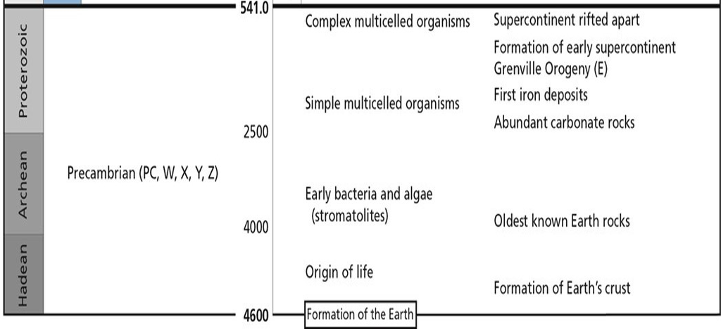

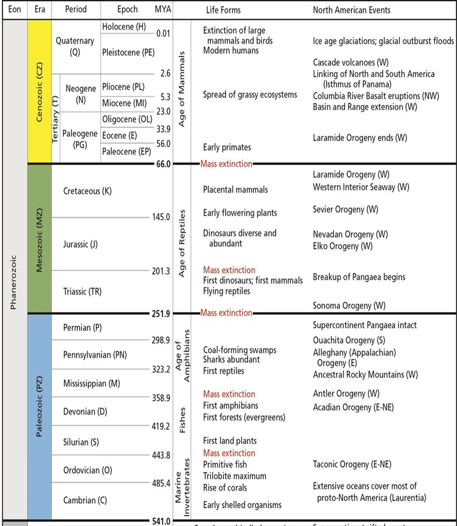

## Key Periods of Human History

- **We know that humans influence the biosphere - just by being humans**
  - local vs regional vs global
- **On geologic times scales humans have existed in the Cenozoic era**
  - our evolutionary trajectory takes us through the Pleistocene and Holocene
  - and at some point a new epoch: *Anthropocene*
- **Understanding the pace of human impacts requires knowledge geologic time scales**

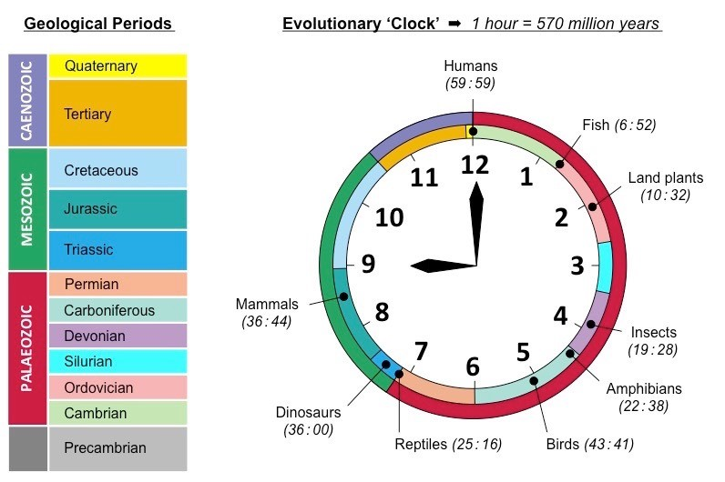

- **Glaciers repeatedly advance from the Arctic over Europe and North America**
  - ice up to a mile thick
  - temperatures ahead of the flow drop significantly.
- **Animal life evolved (or not) to handle temperature change**
  - new species, range shifts, population declines
- **Hominid line continues to evolve during the Pleistocene**
  - anatomically modern humans first appear during late stages
- **More than 200 genera of very large herbivores go extinct**
  - 95% in North America
  - humans and climate

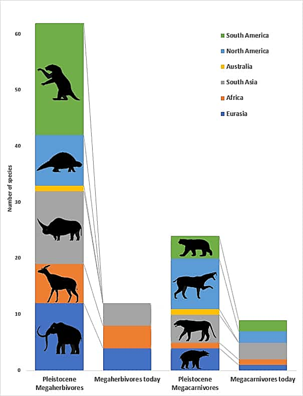

## Appalachian Mountains During the Pleistocene

- **Laurentide Ice Sheet covered the Ohio river valley but did not extend into the southern Appalachians**
- **Mountains were a major climatic refuge for species displaced by glaciers**
  - preserved ancient lineages of *temperate* plants and animals
  - endemic species of Appalachia survived this period
- **Large mammals (mastodons, mammoths) migrated through Appalachian valleys**
- **Post-glacial meltwater created river valleys (e.g., Tennessee and New River basins)**

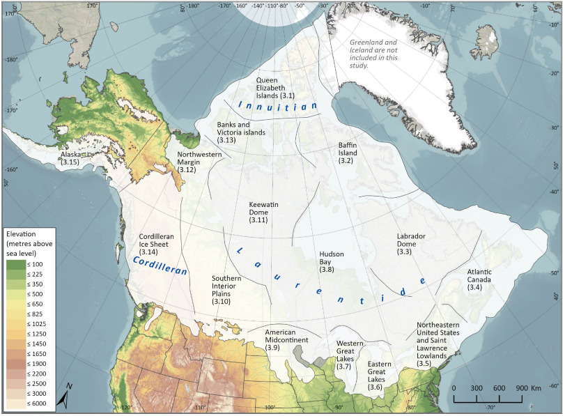

## Holocene (12,000 -)

- **H. sapien the only member of our genus to enter this period**
- **Begins after last glacial period, including glacial retreat**
  - Earth experienced a warming trend
  - perhaps why biodiversity is comparably high
- **Climate change and megafauna extinction drive massive change in human behaviors**
- **Rapid proliferation, growth and impacts of the human species worldwide**

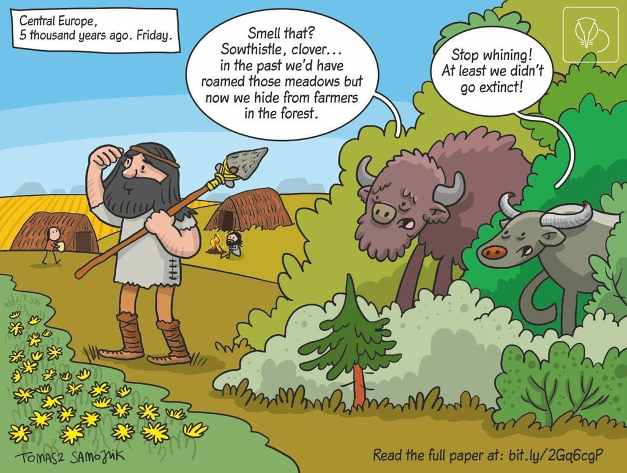

## Holocene: Stable/warm climate benefited humans

- **Significant advancements in technology and ‘urbanization’**
  - resultant increases in human impacts (>local?)

[figure not shown]

## Holocene: Were humans lucky?

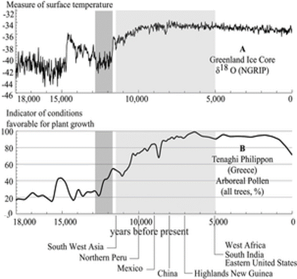

## Neolithic period (12,000-6,000ya)

- **Set of developments that appeared in several places independently!**
- **Development of agriculture = key human landmark**
  - plant cultivation and animal domestication
  - irrigation in areas with insufficient rainfall
  - spread from several centers of origin
- **Origin of agriculture… necessity or opportunity?**
- **Whether from migrating farmers or indigenous development, most continents were transformed**

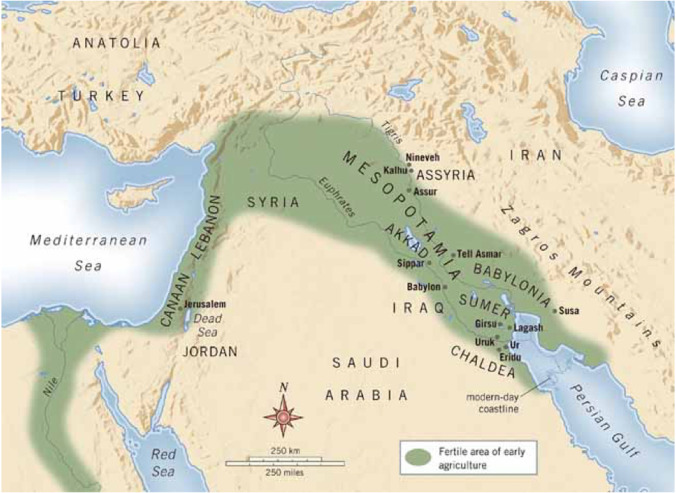

## Neolithic period: Urbanization and Population growth

**Humans persisted in larger and larger populations by manipulating the environment**

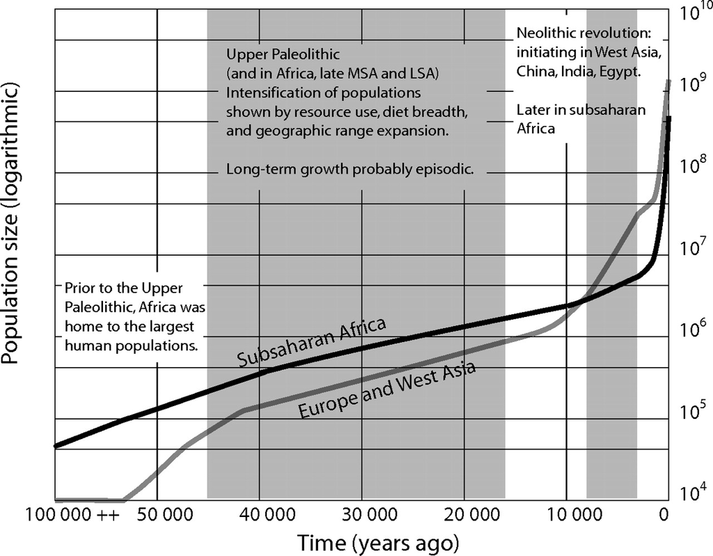

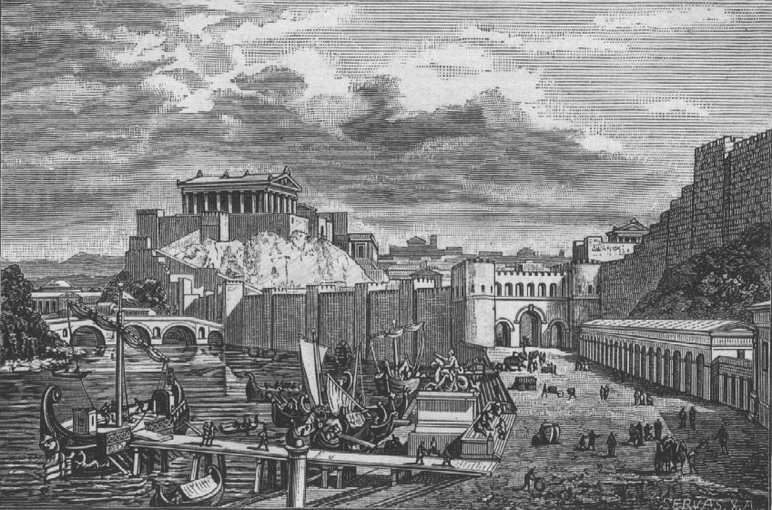

## Health consequences of agriculture…

**Simplifications of our diets also led to a broad simplification of our microbiome (nutrient deficiencies, disease). Archaeological studies reveal nutritional stress in ancient Appalachian populations**

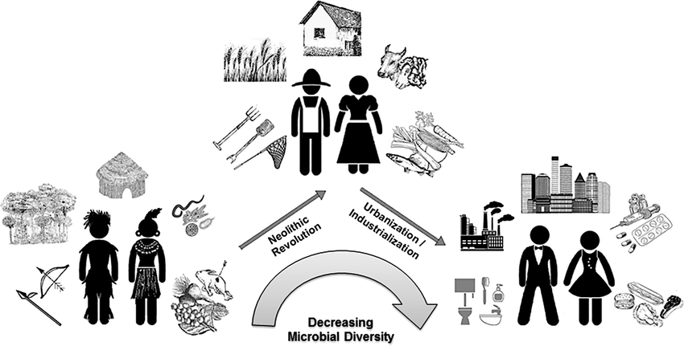

## Appalachian Mountains During the Holocene/Neolithic

- **Earliest indigenous peoples arrived as hunter/gathers**
  - relied on foraging, hunting, and fishing
  - shifted to cultivating native crops
- **Eastern Agricultural Complex: woodlands of eastern North America was 1 of 10 independent centers of plant domestication**
  - sunflower, goosefoot, squash, and maygrass
  - disappeared after maize was introduced
- **Increased sedentism and larger semi-permanent villages along rivers and fertile valleys**
  - regional-scale transition to landscape manipulation and resource intensification.

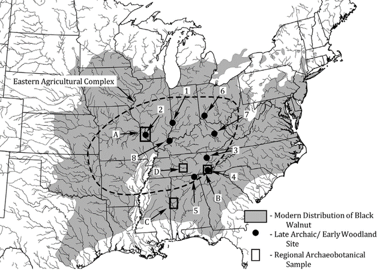

## Late Holocene: Review - Industrial Age (1760 -)

- **Economic and social organization that began around 1760 in Great Britain**
  - factory’s of production (trade, farming, natural resources) allowed it to happen
- **Replacement of hand tools with machines**
  - power loom, steam engine, iron making
- **Appalachian Context: The region became a center for coal mining, fueling industrial growth at the cost of environmental health.**

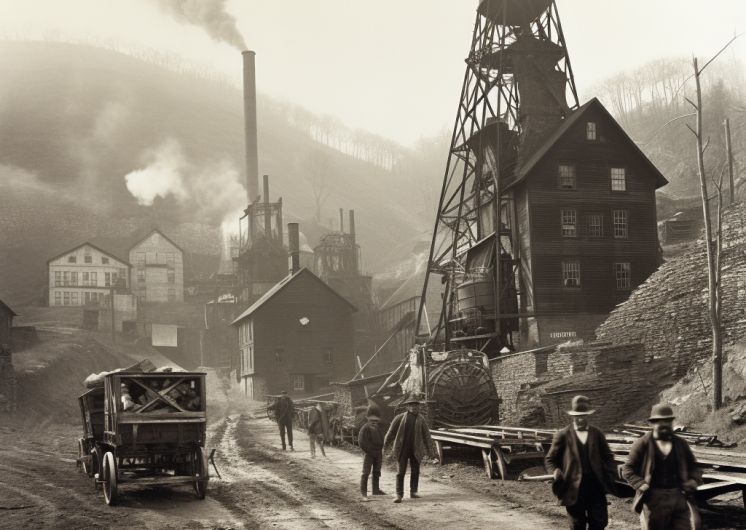

## Late Holocene: Review - Industrial Age (1760 -)

- **Every aspect of daily human life was influenced in some way**
- **Average income and population began to exhibit unprecedented sustained growth**
  - creation of middle class
- **Represents the starting point for serious atmospheric change**
  - based on fossil fuel emissions
  - https://www.youtube.com/watch?v=kCmwKbVFbWg (bar chart race)

[figure not shown]

## NOW: The Great Acceleration

- **Period of rapid socio-economic and environmental following World War II (>1950)**
  - Coincided with the Atomic Age and the Cold War technology race
  - non-official start of the Anthropocene
- **Key drivers: Population boom, industrial expansion, globalization, rise of consumer economies**
  - global population has tripled in just 75 years
- **Introduction of synthetic chemicals, plastics, fertilizers, and global supply chains**
- **Technological growth: Cars, highways, electronics, suburban sprawl**
- **Appalachian context: Infrastructure expansion, coal demand spikes, and federal investments for energy**

## Key Periods of Human History: The Anthropocene Epoch

- **New geologic era?**
  - proposal recently rejected
  - would mark end of the Holocene
- **Many geologist criticize the idea**
  - hard to define a period when you are in it
- **Interval of time where humans dominate key processes on Earth**
  - anthropo, for “man,” and cene, for “new”

[figure not shown]

## Does the Anthropocene begin in the Industrial Age?

[figure not shown]

## Does the Anthropocene begin in the Industrial Age?

[figure not shown]

## Does the Anthropocene begin in the Industrial Age?

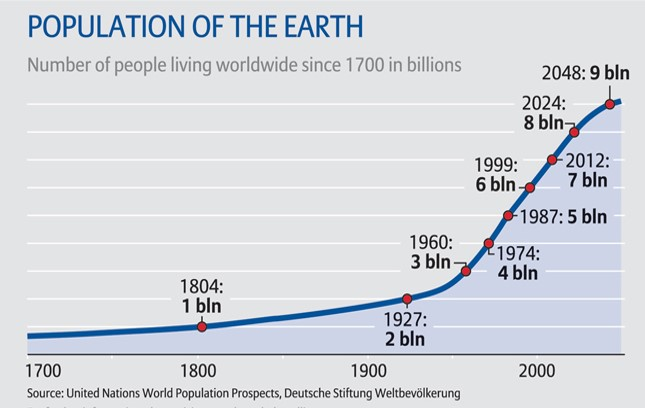

## The Great Acceleration: Post 1950

- **Dramatic, continuous surge in growth rate across a large range of measures of human activity**
- **Socioeconomic parameters: population, economics, water usage, food production, transportation, technology**
- **Earth system parameters: green house gases, surface temperature, and natural resource usage**
- **Post-war revival age**
  - fossil energy and new technology flooding the markets

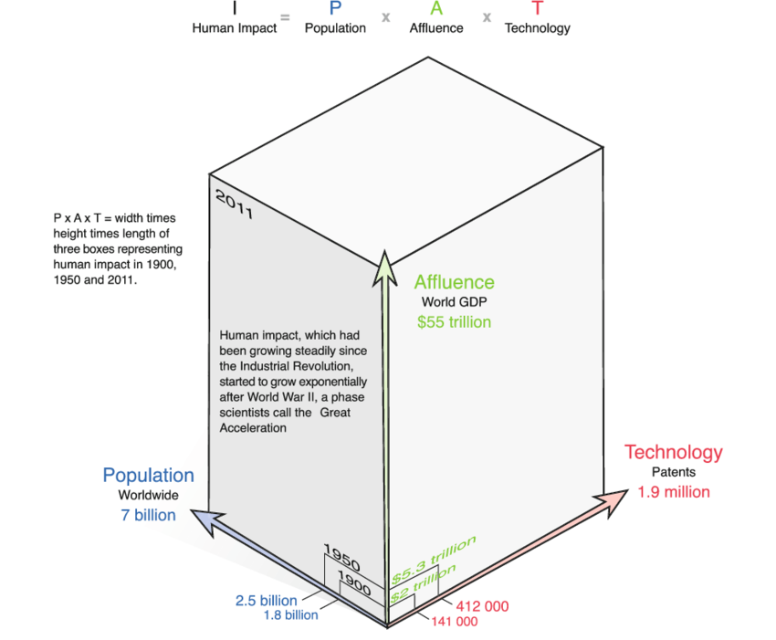

## What happened? Haber Bosch happened!

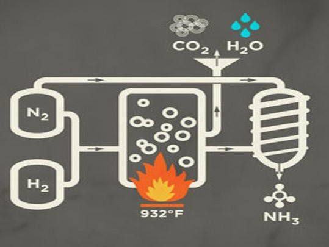

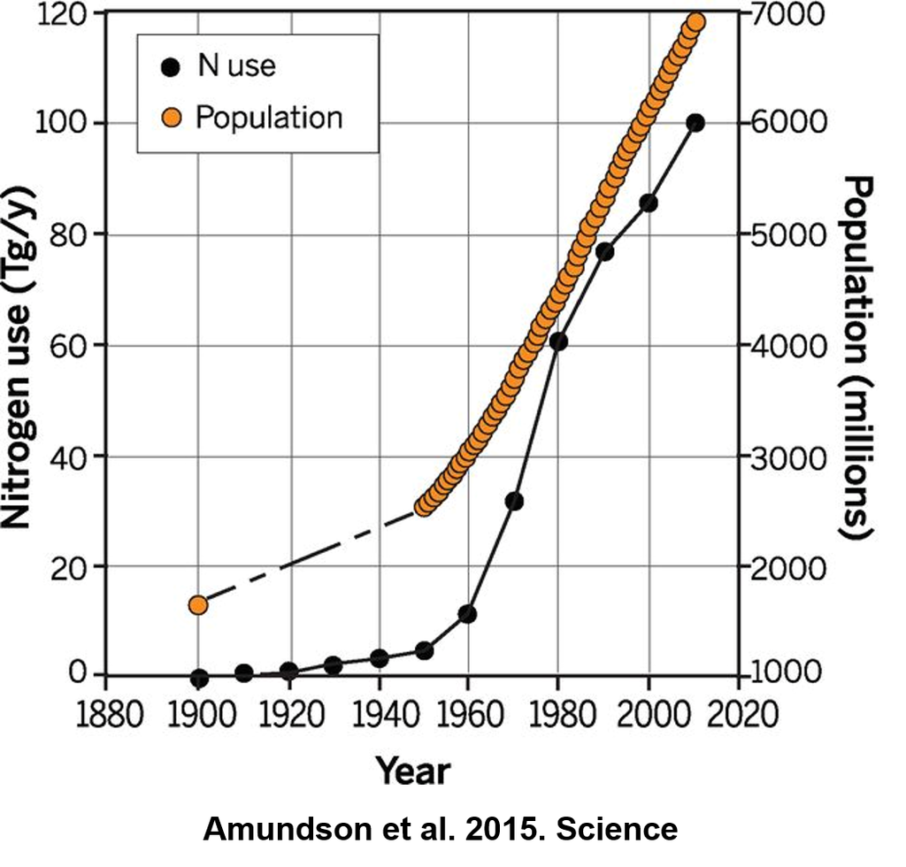

## Appalachia in the Anthropocene: Enviromental

- **Remains a major U.S. coal producer**
  - mountaintop removal flattened 500+ peaks
  - now includes fracking (oil/natural gas) in Marcellus shale
- **Continued land transformation**
  - clear-cutting removed old-growth forests
  - erosion, stream pollution from mining/logging
- **Climate Trends include warmer winters, heavier spring rainfall**

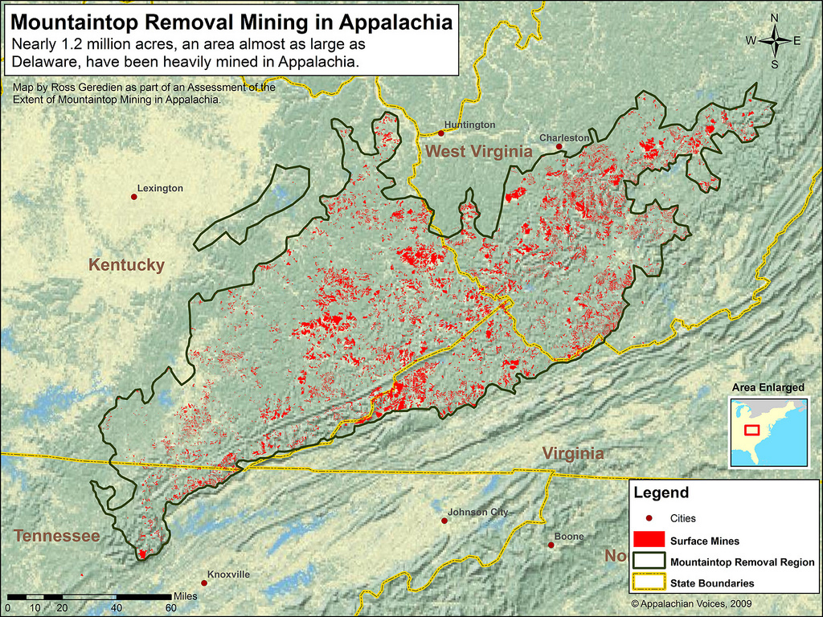

## Appalachia in the Anthropocene: Socieital

- **Boom-Bust Economy: Jobs rose with coal, fell with automation/global shift**
  - Persistent poverty, youth outmigration
- **Health & Justice: Higher rates of cancer, respiratory illness near mining sites**
  - Poor & rural communities hit hardest
- **Resistance Movements: Groups like Appalachian Voices fight for justice**
- **Cultural Resilience:Local stewardship rooted in lived experience**
  - Strong land ties, storytelling, music traditions

[figure not shown]